# Modèle linéaire bayèsien

## I - Introduction

L’objectif principal pour lequel les modèles probabilistes sont gènèralement utilisès est l’évaluation de la loi a posteriori $p(Y | X)$ où $Y$ joue le rôle des variables latentes et $X$ des variables observés. Les espérences sont ensuite calculées à partir de cette loi.
Le concept de l’optimisation variationnelle peut être utilisé pour traiter un problème d’inférence. On se place donc dans le cadre d’un modèle bayésien avec des densités a priori données pour chaque paramètre. Le modèle peut aussi avoir des variables latentes. On désigne par $Y$ les variables latentes et les paramètres, et par $X$ les variables observées. Le modèle considéré est caractérisé par la loi jointe $p(X,Z)$ et l’objectif essentiel et d’approximer la loi a posteriori $p(Z | X)$ ainsi que l’évidence $p(X)$ (dans certains cas on travaille avec le log-évidence pour simplifier). On a dèjà vu qu’on peut décomposer le log-évidence en somme de deux termes intéressants incluant la distance de Kullback Leibler :
$$\begin{equation}
ln p(X) = \mathcal{L}(q) + KL(q||p)
\end{equation}$$
avec
$$\begin{align}
\mathcal{L}(q) &= \int q(Y) ln \left( \frac{p(X,Y)}{q(Y)} \right) dY\\
KL(q||p) &= - \int q(Y) ln \left( \frac{p(Y|X)}{q(Y)} \right) dY
\end{align}$$
L’algorithme considéré permettra de maximiser la borne inférieure $\mathcal{L}(q)$ par rapport aux distributions $q(z)$, ce qui revient de même Ã minimiser la distance $KL$. On va poser une dernière loi de gouvernence qui permettra d’approximer la loi a posteriori : on suppose que les distributions $q$ appartiennent à l’ensemble des lois produits.
Dans le cadre de ce document, on dispose de données $(x_i,y_i)_{i=1..n}$ et on se donne un vecteur de fonctions de base $h=(\phi_1,...,\phi_p)$. On considère le modèle linéaire probabiliste $Y = \phi \theta + \epsilon$ où les $\epsilon = (\epsilon_1,...\epsilon_p)$ sont des bruits gaussiens indépendants tel que $\epsilon \sim \mathcal{N}(0, \beta^{-1} I_n)$. On appelle $\phi$ la matrice de design.
On adope un point de vue gaussien hiérarchique et on impose les priors suivants :
$$\begin{align}
Y|\theta , \beta &\sim \mathcal{N} ( \phi \theta, \beta^{-1} I_n)\\
\theta | \alpha &\sim \mathcal{N} ( 0, \alpha^{-1} I_p)\\
\alpha &\sim Gamma(a_0, \lambda_0)\\
\beta &\sim Gamma(b_0, \tau_0)
\end{align}$$

```r
# Dependencies
library(coda)
library(mvtnorm)
```

## II - Approximation variationnelle

La loi jointe s’écrit de la manière suivante : $p(y, \theta, \alpha, \beta) = p(y|\theta, \beta) p(\theta| \alpha) p(\alpha) p(\beta)$ et on considère l’approximation suivante de la loi a posteriori : $p(\theta, \alpha, \beta | y) = q(\theta, \alpha, \beta) = q_1(\theta) q_2(\alpha) q_3(\beta)$.  
Un calcul un peu long mais facile montre que les solutions de champs moyen $q_1^*$, $q_2^*$, $q_3^*$, vérifient :

$$\begin{align}
q_1^*(\theta) &= \mathcal{N} ( \theta | \tilde{m_n}, \tilde{S_n})\\
q_2^*(\alpha) &= Gamma(\alpha | a_n, \lambda_n)\\
q_3^*(\beta) &= Gamma(\beta | b_n, \tau_n)
\end{align}$$
On se propose d’établir le résultat ci-dessus concernant $\beta$. D’après l’approximation des champs moyens on a :

$$\begin{align}
ln q_3^*(\beta) &= \mathbb{E}_{\theta , \alpha} [ln p(y, \theta, \alpha, \beta)]\\
&= \mathbb{E}_{\theta , \alpha} [ln ( p(y|\theta, \beta) p(\theta| \alpha) p(\alpha) p(\beta) )]\\
&= \mathbb{E}_{\theta , \alpha} [ln p(y|\theta, \beta) + ln p(\beta)] + cte\\
\end{align}$$
Ici on ne garde que les termes qui dépendent de $\beta$, on met tout le reste dans la constante. On connais les lois des variables en question, l’expression devient donc :

$$\begin{align}
ln q_3^*(\beta) &= \mathbb{E}_{\theta , \alpha}[ln \frac{1}{det(\beta^{-1} I_n)^{1/2}}exp (\frac{-1}{2} (y-\Phi \theta)(\beta^{-1}I_n)^{-1}(y-\Phi \theta)^T) + ln \beta^{b_0-1} e^{-\tau_0 \beta}] + cte\\
& = \mathbb{E}_{\theta , \alpha} [ \frac{n}{2} ln(\beta) - \frac{1}{2} (y-\Phi \theta)(\beta I_n)(y-\Phi \theta)^T + (b_0 - 1) ln\beta -\tau_0 \beta]\\
&= \mathbb{E}_{\theta , \alpha} [ (b_0 + \frac{n}{2} - 1 )ln(\beta) - (\tau_0 + \frac{1}{2} (y-\Phi \theta)(y-\Phi \theta)^T) \beta]\\
&= (b_0 + \frac{n}{2} - 1 )ln(\beta) - (\tau_0 + \frac{1}{2} \mathbb{E}_{\theta , \alpha} [||y-\Phi \theta||^2) \beta\\
&= (b_n - 1)ln\beta - \tau_n \beta\\
\Rightarrow q_3^*(\beta) &= cte \times \beta^{b_n -1} e^{-\tau_n \beta}\\
&avec\ \ b_n = b_0 + \frac{n}{2}\ \ \ et \ \ \tau_n = \tau_0 + \frac{1}{2} \mathbb{E}_{\theta , \alpha} [||y-\Phi \theta||^2)
\end{align}$$
Dans la partie suivante, on se propose d’appliquer l’algorithme d’approximation variationnelle par mise à jour successive des équations variationnelles. Pour ce faire, on considère l’expression suivante de la borne inférieur de la log évidence du modèle considéré :
$$\begin{align}
\mathcal{L}(q) &= \mathbb{E}_q(ln\frac{p(y, \theta, \alpha, \beta)}{q(\theta, \alpha, \beta)})\\
&= \mathbb{E}_{q^*}(ln p(y | \theta, \beta)) + \mathbb{E}(ln p(\theta | \alpha)) + \mathbb{E}_{q^*}(ln p(\alpha)) + \mathbb{E}_{q^*}(ln p(\beta))\\ &- \mathbb{E}_{q^*}(ln q^*(\theta)) - \mathbb{E}_{q^*}(ln q^*(\alpha)) - \mathbb{E}_{q^*}(ln q^*(\beta))
\end{align}$$
On considère les fonction *variational_lowerbound* et *variational_update* suivantes. La première sert à calculer la borne inférieure Ã partir des valeurs de la variable cible, des paramètres et des hyperparamètres prises comme entrée. Tant dis que la deuxième met à jour les valeurs des paramètres qu’on a trouvés par approximation des champs moyens.

```r
variational_lowerbound <- function(Phi, target, varpar , hyperpar)
  ## ARGUMENTS:
  ## Phi: design matrix (feature map applied to data): a n*p matrix
  ## target: a  vector of size n: the observed values y.
  ## varpar: a list of variational parameters containing the following entries:
  ##     m_n: variational expectancy of theta
  ##     S_n: variational covariance of theta
  ##     a_n, lambda_n: variational gamma parameters  for alpha (prior concentration of theta)
  ##     b_n, tau_n: variational gamma parameters for beta (prior concentration of noise)
  ## hyperpar: a list of hyperparameters containing the following entries:
  ##     a_0, lambda_0 b_0  tau_0:   hyper-prior gamma parameters respectively for alpha and beta
  ##
## RETURNS: the variational lower bound
{
  list2env(varpar, envir=environment())
  list2env(hyperpar, envir = environment() )

  n <- length(target)
  p <- ncol(Phi)

  Elnp_y <- n/2 *(- log(2*pi) + digamma( b_n) - log(tau_n)) -
    b_n/(2*tau_n) * (sum( (target - Phi%*%m_n)^2 ) + sum(diag( Phi%*%S_n%*%t(Phi))))

  Elnp_theta <- p/2 * (- log(2*pi) + digamma( a_n) - log(lambda_n)) -
    a_n/(2* lambda_n) * ( sum(m_n^2) + sum(diag( S_n))  )

  Elnp_alpha <- a_0 * log(lambda_0) + (a_0 - 1) * (digamma( a_n) - log(lambda_n)) -
    lambda_0 * (a_n / lambda_n) - lgamma(a_0)


  Elnp_beta <- b_0 * log(tau_0) + (b_0 - 1) * (digamma( b_n) - log(tau_n)) -
    tau_0 * (b_n / tau_n) - lgamma(b_0)

  Elnq_theta <- - p/2 * (1 + log(2*pi)) - 1/2 * log(det( S_n))
  Elnq_alpha <- - lgamma(a_n) + (a_n - 1) * digamma( a_n ) + log(lambda_n) - a_n
  Elnq_beta <- - lgamma(b_n) + (b_n - 1) * digamma( b_n ) + log(tau_n) - b_n

  lowerbound <- Elnp_y + Elnp_theta + Elnp_alpha +  Elnp_beta - Elnq_theta - Elnq_alpha - Elnq_beta

  return(lowerbound)

}
```

```r
variational_update <- function(Phi, target,
                               currentpar, hyperpar)
  ## Phi: design matrix (feature map applied to data): a n*p matrix
  ## target: a  vector of size n: the observed values y.
  ## varpar: a list of variational parameters containing the following entries:
  ##     m_n: variational expectancy of theta
  ##     S_n: variational covariance of theta
  ##     a_n, lambda_n: variational gamma parameters  for alpha (prior concentration of theta)
  ##     b_n, tau_n; variational gamma parameters for beta (prior concentration of noise)
  ## hyperpar: a list of hyperparameters containing the following entries:
  ##     a_0, lambda_0, b_0,  tau_0:   hyper-prior gamma parameters respectively for alpha and beta
  ##
  ## RETURNS: a list of the same format as varpar containing the updated parameters.
{
  list2env(currentpar, envir=environment())
  list2env(hyperpar, envir = environment() )
  n <- length(target)
  p <- ncol(Phi)

  S_n_inv <- a_n/lambda_n * diag(p) + b_n/tau_n * t(Phi)%*%Phi
  S_n <-  solve(S_n_inv)
  m_n <-  b_n / tau_n * S_n %*% t(Phi) %*% target
  a_n <- a_0 + p/2
  lambda_n <- lambda_0 + 1/2 * (sum(m_n^2) + sum(diag(S_n)) )
  b_n <- b_0 + n/2
  tau_n <- tau_0 + 1/2 * ( sum( ( target - Phi %*% m_n)^2 ) + sum(diag(Phi %*% S_n%*% t(Phi)))  )
  return(list(m_n = m_n, S_n = S_n, a_n = a_n, lambda_n = lambda_n, b_n = b_n, tau_n = tau_n))

}
```

L’algorithme *variational_lm* fournit tout le travail d’approximation variationnelle. En prenant des valeurs d’initialisation quelconque (mais bien sûr vérifiant les conditions de dimension), il met à jour ces paramètres là à l’aide de la fonction *variational_update*. Ensuite, en fonction des paramètres mis à jour, il calcule la borne inférieure correspondante à l’aide de la fonction *variational_lowerbound*. On teste ensuite la convergence de l’algorithme en comparant la borne inférieure retrouvée à une valeur donnée de tolérence. Pour éviter que l’algorithme bloque, on ajoute comme entrée le nombre maximal d’itérations à ne pas dépasser.

```r
variational_lm <- function(Phi, target,  hyperpar,  maxiter = 100, tol = 1e-4)
  ## ARGUMENTS:
  ## Phi: design matrix (feature map applied to data): a n*p matrix
  ## target: a  vector of size n: the observed values y.
  ## hyperpar: a list of hyperparameters containing entries a_0, lambda_0, b_0, tau_0:
  ##          hyper-prior gamma parameters respectively for alpha and beta
  ## maxiter: the maximum number of variational updates
  ## tol: the stopping criterion for the variational updates: the algorithm stops if the
  ##     standard deviation of the variational lower bound  over the latest 5 iterations
  ## is less than tol.
  ##
  ## RETURNS:  a list with entries (convergence, var_par, lowerbound, niter)
##     convergence = 0 if the stopping criterion was met (successful convergence), 1 otherwise.
##     var_par: a list containing the variational parameters at the last iteration, that is
##           (m_n, S_n, a_n, lambda_n, b_n, tau_n)
##     lowerbound: the lower bound values across all iterations of the optimisation algorithm.
##     niter: the number of iterations performed.
{
  n <- length(target)
  p <- ncol(Phi)
  list2env(hyperpar, envir=environment())
  ## list2env makes all elements of the list visible from the function's environment.

  ## Initialization
  niter <- 0 ## number of iterations performed
  currentpar <- list(m_n =  matrix(0, p, 1) ,
                     S_n =  diag(p) ,
                     a_n =  0.1 ,
                     lambda_n = 0.1 ,
                     b_n = 0.1  ,
                     tau_n = 0.1)
  lowerbound <- c() ## empty vector.
  delta <- tol+1  ## stopping criterion not satisfied at the initialization step
  continue <- TRUE
  while(continue)
  {
    currentpar = variational_update(Phi, target, currentpar, hyperpar)
    lowerbound = c(lowerbound, variational_lowerbound(Phi, target, currentpar, hyperpar))
    niter = niter + 1
    ##  the stopping criterion is implemented below:
    if(niter >5){
      delta <- sd(lowerbound[niter:(niter-5) ])
      if(delta <tol){ continue <- FALSE}
    }
  }
  if (delta < tol ){ cv <- 0} else{cv <- 1}
  return(list( convergence = cv , varpar = currentpar, lowerbound = lowerbound, niter = niter  ))
}
```

```r
Beta0 <- 0.1

theta0 <- c(5, 2,1,-1,1)
Fmap = function(x){c(1, x, x^2, x^3, x^4)}
N <- 100
set.seed(3)
#'  allows result reproductibility  (sets the seed of the random number generator)
data_4 <- matrix(runif(N, min=-3, max = 3),ncol=1)
Phi_4 = matrix(sapply(data_4, Fmap), 100, 5, byrow=TRUE)
target_4 <-  Phi_4%*%theta0 + rnorm(N, sd = sqrt(Beta0)^(-1))
hyperpar <- list(a_0=0.1, lambda_0=0.1, b_0=0.1, tau_0=0.1)
L = variational_lm(Phi_4, target_4, hyperpar, maxiter = 100, tol =1e-4)
```

Dans le but d’évaluer la pertinence des résultats trouvés, on tracera sur un même graph le vrai vecteur $\theta_0$, l’espérence a posteriori de chaque élément de $\theta$ dans l’approximation variationnelle et les intervalles de crédibilité a posteriori à $95\%$ basés sur les quantiles a posteriori pour chaque élément de $\theta$.

```r
data_4 <- matrix(data_4[1:N], ncol=1)
target_4<- matrix(target_4[1:N], ncol=1)
Iplus <- L$varpar$m_n + 1.96*sqrt(diag(L$varpar$S_n))
Iminus <- L$varpar$m_n - 1.96*sqrt(diag(L$varpar$S_n))
plot(theta0, pch=19,col='black',main = paste(" N = ", toString(N), sep=""), ylim =
       range(Iminus, Iplus, theta0))
points(L$varpar$m_n, col='red')
```

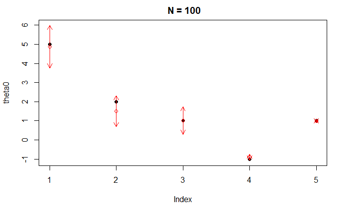

```r
arrows( x0 = 1:5, y0 = Iminus,
        y1 = Iplus ,code=3, length=0.1, col="red")
```

On remarque que la fonction *arrows* nous permet de voir que les valeurs estimées a posteriori sont très proches des valeurs réelles de $\theta$. Ceci dit, on va comparer plus tard ces résultats avec les résultats de la mèthode “empirical Bayes” vue au premier TP. Mais avant, comparons l’espérence de $\beta$ a posteriori sous $q^*$ avec la vraie valeur $\beta_0$. Pour ce faire, on utilisera un intervalle de crédibilité a posteriori à $95\%$ basé sur le quantile a posteriori de $\beta$

```r
q = qgamma(0.95, shape = L$varpar$b_n, rate = L$varpar$tau_n)
Exp = L$varpar$b_n / L$varpar$tau_n
Iplus <- Exp + q
Iminus <- Exp - q
plot(Beta0, pch=19,col='black',main = paste(" N = ", toString(N), sep=""), ylim =
       range(Iminus, Iplus, Beta0))
points(Exp, col='red')
```

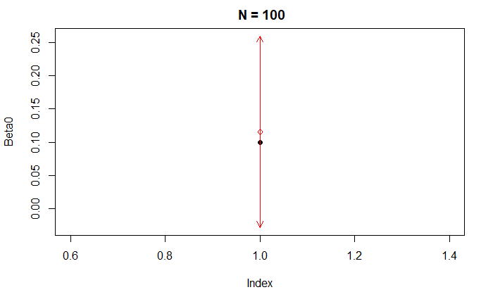

```r
arrows( x0 = 1, y0 = Iminus,
        y1 = Iplus ,code=3, length=0.1, col="red")
```

On remarque que la valeur du paramètre $\beta$ se trouve bien dans l’intervalle de crédibilité, de plus elle est proche de la vraie valeur du paramètre, ce qui affirme encore la pertinence du modèle choisi.

On arrive maintenant à l’étape où on va comparer les résultats de la *méthode variationnelle* avec ceux de la méthode *empirical bayes*. Pour ce faire, on considère les deux fonctions qu’on a utilisé au premier tp *glinear_fit* et *logevidence*. On veut comparer les valeurs optimales $\alpha^*$ et $\beta^*$ de la méthode *empirical bayes* avec $\mathbb{E}_{q^*}(\alpha)$ et $\mathbb{E}_{q^*}(\beta)$ de la *méthode variationnelle*.

```r
glinear_fit <- function(Alpha, Beta, data, feature_map, target)
    #' ARGUMENTS:
    #' Alpha: prior precision on theta
    #' Beta: noise precision
    #' data: the input variables (x): a matrix with n rows where n is the sample size
    #'feature_map: the basis function, returning a vector of  size p equal to the dimension of theta
    #' target: the observed values y: a vector of size n
    #' RETURNS: a  list with entries (mean, cov) (osterior mean and variance)
  {

    Phi <-  t(apply(X= data, MARGIN=1, FUN = feature_map))
    p = ncol(Phi)
    posterior_variance_inverse <-  diag(x=Alpha, nrow= p) +
      Beta * t(Phi)%*%Phi
    posterior_variance <-  solve(posterior_variance_inverse)
    posterior_mean <-   Beta *
      posterior_variance %*% t(Phi)%*% target
    return(list(mean=posterior_mean, cov=posterior_variance))
  }
```

```r
logevidence <- function(Alpha, Beta, data ,feature_map, target)
    ## ARGUMENTS:
    ## Alpha: prior precision for theta
    ## Beta: noise precision
    ## data: the input points x_{1:n}
    ## feature_map: the vector of basis functions
    ## target: the observed values y: a vector of size n.
    ## RETURNS: the logarithm of the model evidence forthe considered dataset.
  {
    Phi_transpose <-  apply(X= data, MARGIN=1, FUN = feature_map)
    if(is.vector(Phi_transpose)){
      Phi_transpose = matrix(Phi_transpose,nrow=1)
    }
    Phi <- t(Phi_transpose)
    N <- nrow(Phi)
    p <- ncol(Phi)
    A <- Alpha*diag(p) + Beta * Phi_transpose %*% Phi
    postmean <- Beta * solve(A) %*% Phi_transpose %*% target
    energy <- Beta/2 * sum(( target - Phi%*%postmean)^2) + Alpha/2 * sum((postmean)^2)
    res <- p/2 * log(Alpha) + N/2 * log(Beta) - energy - 1/2 * log(det(A)) - N/2 * log(2*pi)
    return(res)
  }
```

```r
optAB <- optim(par=c(1, 1),
               fn=function(par){-logevidence(Alpha=par[1], Beta=par[2], data_4 ,feature_map=Fmap, target_4)},
               method = "L-BFGS-B",
               lower=c(0.1 , 0.1), upper = c(250,30))
optAB$par
```

```
[1] 0.1690487 0.1155917
```

```r
c(L$varpar$a_n/L$varpar$lambda_n, L$varpar$b_n/L$varpar$tau_n)
```

```
[1] 0.1751109 0.1157912
```

```r
# Les valeurs des paramètres alpha et beta estimés par les deux méthodes sont quasiment les mêmes !
```

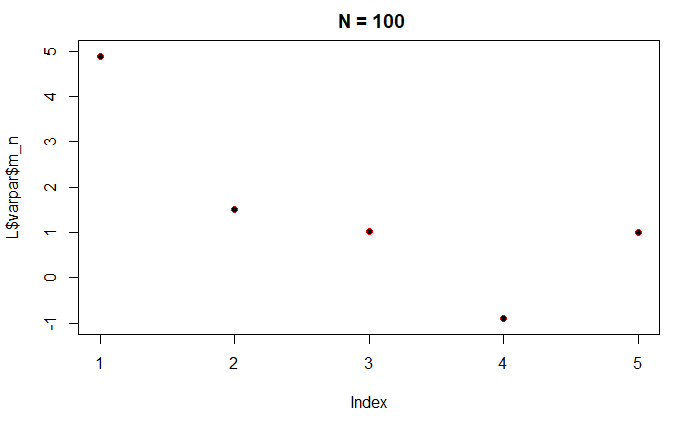

```r
mfit <- glinear_fit(Alpha = optAB$par[1], Beta = optAB$par[2],
                      data= data_4, feature_map = Fmap, target = target_4)
  plot(L$varpar$m_n, pch=19,col='black',main = paste(" N = ", toString(N), sep=""), ylim = range(Iminus, Iplus, theta0))
  points(mfit$mean, col='red')
```

```r
# Les valeurs estimées de theta est la même pour les deux méthodes, nous avons une superposition !
```

### Choix du modèle :

On considère maintenant le problème de prédiction de la distance d’arrêt en fonction de la vitesse du véhicule. On utilise pour cela le jeu de données *cars* de *R*. On adope le même modèle de régression linéaire sur une base de fonctions polynomiales comme décrit précédemment. On cherche à determiner maximal de la base polynomiale adoptée, c’est-à-dire qu’on veut adapter la dimension au jeu de données.

```r
data(cars)
names(cars)
```

```
[1] "speed" "dist"
```

```r
F6 <- function(x){c(1, x, x^2, x^3, x^4, x^5, x^6)}
F5 <- function(x){c(1, x, x^2, x^3, x^4, x^5)}
F4 <- function(x){c(1, x, x^2, x^3, x^4)}
F3 <- function(x){c(1, x, x^2, x^3)}
F2 <- function(x){c(1, x, x^2)}
F1 <- function(x){c(1, x)}
F0 <- function(x){1}
listF=list(F0,F1,F2,F3,F4,F5,F6)
```

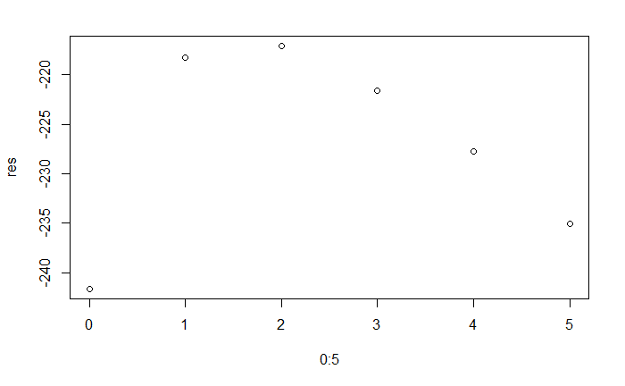

```r
feature_cars = matrix(cars$speed, ncol=1)
target_cars = cars$dist
# Pour des degrés supérieurs à 4, S_n devient singulière
res <- sapply(0:5,FUN=function(i){
  Phi_temp = matrix(sapply(feature_cars, listF[[i+1]]), 50, i+1, byrow=TRUE)
  temp = variational_lm(Phi_temp, target_cars, hyperpar ,maxiter = 100, tol =1e-4)
  temp$lowerbound[temp$niter]
})
plot(0:5, res)
```

```r
best_degre = which.max(res) - 1
```

```r
  ### Le degré du meilleur polynôme est égal à 2
```

### Prédictive approchée dans l’approximation variationnelle :

Dans cette partie, on continue à considérer le jeu de données *cars*. On utilise une nouvelle abscisse $x_{new}$ dans l’intervalle $[0,25]$ à laquelle on associe une nouvelle abscisse $Y_{new} = <h(x), \theta> + \epsilon$ avec $\epsilon \sim \mathcal{N}(0,\beta^{-1})$ et telle que $(\theta, \beta)$ sont distribués selon la loi a posteriori. On utilise ici l’approximation variationnelle de la loi a posteriori et on remplace la composante $q_3^*(\beta)$ par $\mathbb{E}_{q_3^*}(\beta)$. En effet, le calcul de la variance de la loi a posteriori de $\beta$ (ie, $b_n / \tau_n^2$), donne une valeur très faible (de l’ordre de $10^{-2}$. Ce qui rend notre approximation legitime vu que la loi a posteriori de $\beta$ tendrait vers une dirac. On se propose à présent de caractériser la loi prédictive a posteriori $\mathbb{E}(Y_{new} | y_{1:n})$ sachant les valeurs de $x_{new}$.
$$\begin{align}
p(Y_{new} | x_{new}, y_{1:n}) &=^{(a)}\int_{\theta} \int_{\alpha} \int_{\beta} p(Y_{new} | x_{new}, \theta, \alpha, \beta)p(\theta, \alpha, \beta, | y_{1:n})d\theta d\alpha d\beta\\
&=^{(b)} \int_{\theta} \int_{\alpha} \int_{\beta} p(Y_{new} | x_{new}, \theta, \alpha, \beta)q_1^*(\theta)q_2^*(\alpha)q_3^*(\beta)d\theta d\alpha d\beta\\
&=^{(c)} \int_{\theta} \int_{\alpha}p(Y_{new} | x_{new}, \theta, \alpha, \mathbb{E}_{q_3^*}(\beta))q_1^*(\theta)q_2^*(\alpha)d\theta d\alpha\\
&=^{(d)}\int_{\theta} \mathcal{N}(Y_{new}; \phi \theta, (\frac{b_n}{\tau_n})^{-1} I_n) \mathcal{N}(\theta; \tilde{m_n}, \tilde{S_n}) d\theta \int_{\alpha} q_2^*(\alpha)d\alpha\\
&=\int_{\theta} \mathcal{N}(Y_{new}; \phi \theta, (\frac{b_n}{\tau_n})^{-1} I_n) \mathcal{N}(\theta; \tilde{m_n}, \tilde{S_n}) d\theta\\
&= \mathcal{N}(Y_{new}; \phi(x_{new}) \tilde{m_n}, \sigma^2(x_{new}))\\
avec\ \ \sigma^2(x) &= \frac{\tau_n}{b_n} + \phi(x)^T \tilde{S_n} \phi(x)
\end{align}$$
On peut maintenant tracer la loi de $\mathbb{E}(Y_{new} | y_{1:n})$ en fonction des $x_{new}$. Dans le même graph, on fait apparaitre le jeu des données ainsi que les quantiles $0.975$ et $0.025$.

```r
Phi_best = matrix(sapply(feature_cars, listF[[best_degre+1]]), 50, best_degre+1,
                  byrow=TRUE)
temp = variational_lm(Phi_best, target_cars, hyperpar ,maxiter = 100, tol =1e-4)
theta_pred = temp$varpar$m_n
test = 1:25
Phi_test = matrix(sapply(test, listF[[best_degre+1]]), 25, best_degre+1, byrow=TRUE)
Etarget_fit <-  Phi_test%*%theta_pred
# Calcul de la variance
variance_new <- temp$varpar$tau_n/temp$varpar$b_n + Phi_test%*% temp$varpar$S_n %*% t(Phi_test)
# Calcul des quantiles à 0.975 et 0.025
ymax = Etarget_fit + 1.96 * sqrt(diag(variance_new))
ymin = Etarget_fit - 1.96 * sqrt(diag(variance_new))
# Plot graphique des résultats
plot(cars$speed, cars$dist)
points(1:25, Etarget_fit, col='blue')
```

```r
lines(ymax, col='red')
lines(ymin, col='red')
```

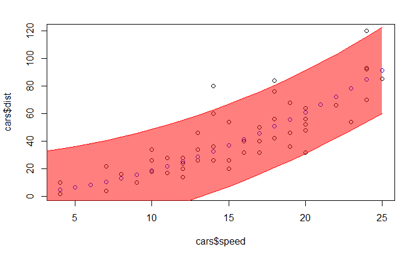

```r
polygon(c(test, rev(test)), c(ymax, rev(ymin)),
        col=rgb(1, 0, 0,0.5), border = NA)
```

On remarque que la plupart des points du jeu de données appartiennent effectivement à l’intervalle de crédibilité. Quoique, cet intervalle de crédibilité peut être encore raffiner surtout pour des valeurs faible de $x_{new}$